# Introduction

When it comes to the job market surronding data scientists, many people do not know where to start because of all of the daunting job titles and other things that come with applying. The purpose of this project is to take a dataset about the pay of data scientists and really breakdown what is going on and how a new data scientist can break into the field and put themselves out there. Knowing what you should be paid and what others are being paid is a very string tool as a interviewee and can allow you to get an upperhand when in an interview

# 6-10 Questions

```python
import matplotlib.pyplot as plt
plt.style.use('fivethirtyeight')
import math
from scipy import stats
import numpy as np
import pandas as pd
import warnings
warnings.simplefilter(action='ignore', category=np.VisibleDeprecationWarning)
```

```python
from google.colab import drive
drive.mount('/content/drive')
```

```python
%cd /content/drive/MyDrive/Colab\ Notebooks/
```

```
/content/drive/MyDrive/Colab Notebooks
```

```python
!jupyter nbconvert --to html Ds220_Final.ipynb
```

```
[NbConvertApp] Converting notebook Ds220_Final.ipynb to html
[NbConvertApp] Writing 1184950 bytes to Ds220_Final.html
```

```python
file_path = 'v7_Latest_Data_Science_Salaries.csv'
df = pd.read_csv(file_path)
df
```

|  | Job Title | Employment Type | Experience Level | Expertise Level | Salary | Salary Currency | Company Location | Salary in USD | Employee Residence | Company Size | Year |
| --- | --- | --- | --- | --- | --- | --- | --- | --- | --- | --- | --- |
| 0 | Data Engineer | Full-Time | Mid | Intermediate | 138000 | United States Dollar | United States | 138000 | United States | Medium | 2024 |
| 1 | Data Engineer | Full-Time | Mid | Intermediate | 86000 | United States Dollar | United States | 86000 | United States | Medium | 2024 |
| 2 | Data Analyst | Full-Time | Entry | Junior | 179000 | United States Dollar | United States | 179000 | United States | Medium | 2024 |
| 3 | Data Analyst | Full-Time | Entry | Junior | 112000 | United States Dollar | United States | 112000 | United States | Medium | 2024 |
| 4 | Business Intelligence Developer | Full-Time | Mid | Intermediate | 92000 | United States Dollar | United States | 92000 | United States | Medium | 2024 |
| ... | ... | ... | ... | ... | ... | ... | ... | ... | ... | ... | ... |
| 5731 | Data Scientist | Full-Time | Senior | Expert | 412000 | United States Dollar | United States | 412000 | United States | Large | 2020 |
| 5732 | Principal Data Scientist | Full-Time | Mid | Intermediate | 151000 | United States Dollar | United States | 151000 | United States | Large | 2021 |
| 5733 | Data Scientist | Full-Time | Entry | Junior | 105000 | United States Dollar | United States | 105000 | United States | Small | 2020 |
| 5734 | Business Data Analyst | Contract | Entry | Junior | 100000 | United States Dollar | United States | 100000 | United States | Large | 2020 |
| 5735 | Data Science Manager | Full-Time | Senior | Expert | 7000000 | Indian Rupee | India | 94665 | India | Large | 2021 |

5736 rows × 11 columns

```python
df.columns.tolist()
```

```
['Job Title',
 'Employment Type',
 'Experience Level',
 'Expertise Level',
 'Salary',
 'Salary Currency',
 'Company Location',
 'Salary in USD',
 'Employee Residence',
 'Company Size',
 'Year']
```

# Expertise level

```python
Newdf1 = df.loc[:, ['Experience Level', 'Salary in USD']]
Newdf1
```

|  | Experience Level | Salary in USD |
| --- | --- | --- |
| 0 | Mid | 138000 |
| 1 | Mid | 86000 |
| 2 | Entry | 179000 |
| 3 | Entry | 112000 |
| 4 | Mid | 92000 |
| ... | ... | ... |
| 5731 | Senior | 412000 |
| 5732 | Mid | 151000 |
| 5733 | Entry | 105000 |
| 5734 | Entry | 100000 |
| 5735 | Senior | 94665 |

5736 rows × 2 columns

[output not shown]

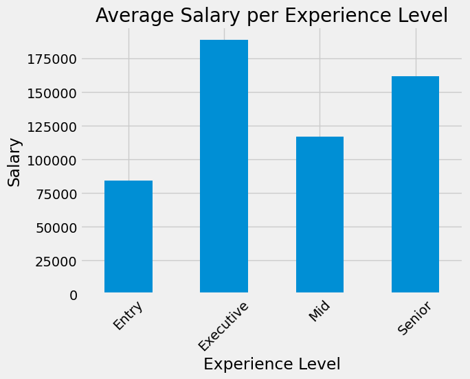

```python
average_salary_per_location = Newdf1.groupby('Experience Level')['Salary in USD'].mean()
average_salary_per_location.plot(kind='bar')
plt.xlabel('Experience Level')
plt.ylabel('Salary')
plt.title('Average Salary per Experience Level')

plt.xticks(rotation=45)
```

Here we can see that that experience level does effect how much a data scientist gets paid. This is something that we expected but the gap between junior and director is much more than expected

# what are the most common Job Titles? do job titles correlate with experience?

```python
Job_count = df['Job Title'].value_counts()
Job_count_df = pd.DataFrame(Job_count.items(), columns=['Job Title', 'Count'])
Job_count_df
```

|  | Job Title | Count |
| --- | --- | --- |
| 0 | Data Engineer | 1097 |
| 1 | Data Scientist | 1051 |
| 2 | Data Analyst | 772 |
| 3 | Machine Learning Engineer | 542 |
| 4 | Analytics Engineer | 218 |
| ... | ... | ... |
| 127 | BI Data Engineer | 1 |
| 128 | Managing Director Data Science | 1 |
| 129 | Sales Data Analyst | 1 |
| 130 | Marketing Data Scientist | 1 |
| 131 | AWS Data Architect | 1 |

132 rows × 2 columns

based off of this table, we can observe that the titles with the highest counts are: Data Engineer, Data scientist, Data analyst and then it starts to fall off a bit. Using this allows us to see the variety of Data Science and all the different applications has. This DataSet only has 5000 entries and there is still 130 job titles. Showing that people with many different interests can get into Data Science.

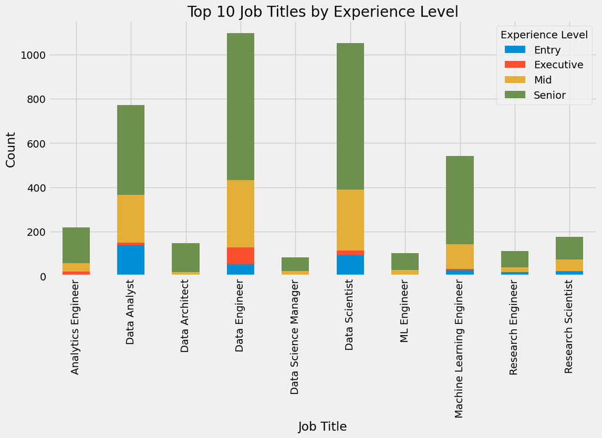

```python
top_job_titles = df['Job Title'].value_counts().head(10).index.tolist()
df_top_n = df[df['Job Title'].isin(top_job_titles)]
count_data = df_top_n.groupby(['Job Title', 'Experience Level']).size().unstack(fill_value=0)
count_data.plot(kind='bar', stacked=True, figsize=(12, 6))
plt.title(f'Top {10} Job Titles by Experience Level')
plt.xlabel('Job Title')
plt.ylabel('Count')
plt.xticks(rotation=90)
plt.legend(title='Experience Level')
plt.show()
```

In this graph we can see the top 10 Job titles in our dataset (too many job titles to include all) of these top 10 job titles, it is easy to observe that a majority of them are controlled by senior data scientists showing to an entry level data scientist that maybe these are some titles to stay away from until they have some experience under thier belt.

# What Job Title has the Best Pay?

[output not shown]

[figure not shown]

```python
verage_salary= df.groupby('Job Title')['Salary in USD'].mean()
top_countries = verage_salary.sort_values(ascending=False).head(10)
top_countries.plot(kind='bar')
plt.xlabel('Job Title')
plt.ylabel('Average Salary')
plt.xticks(rotation=80)
```

# What country has the best pay?

```python
Newdf = df.loc[:, ['Company Location', 'Salary in USD']]
Newdf
```

|  | Company Location | Salary in USD |
| --- | --- | --- |
| 0 | United States | 138000 |
| 1 | United States | 86000 |
| 2 | United States | 179000 |
| 3 | United States | 112000 |
| 4 | United States | 92000 |
| ... | ... | ... |
| 5731 | United States | 412000 |
| 5732 | United States | 151000 |
| 5733 | United States | 105000 |
| 5734 | United States | 100000 |
| 5735 | India | 94665 |

5736 rows × 2 columns

[output not shown]

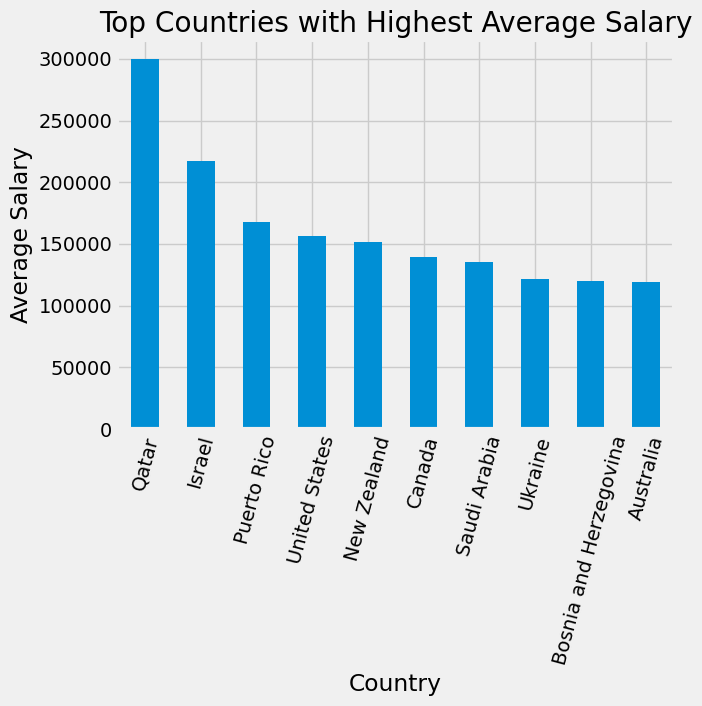

```python
average_salary_per_location = Newdf.groupby('Company Location')['Salary in USD'].mean()
top_countries = average_salary_per_location.sort_values(ascending=False).head(10)
top_countries.plot(kind='bar')
plt.title('Top Countries with Highest Average Salary')
plt.xlabel('Country')
plt.ylabel('Average Salary')
plt.xticks(rotation=75)
```

Qatar looks very high compared to the other countries. Lets see if it is an outlier.

```python
qatar_data = Newdf[Newdf['Company Location'] == 'Qatar']
qatar_data
```

|  | Company Location | Salary in USD |
| --- | --- | --- |
| 2711 | Qatar | 300000 |

Here we see a prime example of we can get things wrong whne looking at datasets. Before we thought it was clear that qatar was the highest paying country to be a data scientist in, but after closer inspection we can infer that this is most likelt wrong because there was only one entry for Qatar. meaning that the data is very skewed in Qatars favor. So because we dont have enough data to support Qatar being the best country to be in

```python
israel_data = Newdf[Newdf['Company Location'] == 'Israel']
israel_data
```

|  | Company Location | Salary in USD |
| --- | --- | --- |
| 3375 | Israel | 115000 |
| 4019 | Israel | 417937 |
| 5727 | Israel | 119059 |

Just to make sure I did the same with israel and they do not have many entries either and had an extreme outlier, raising their average by a lot. Thus meaning that maybe it wasnt the best either.

**What can we collect from this?**

Although the top entries are skewed it can stil give us a better idea of what countries are on the higher side of the salary spectrum.

# Does Company size impact Salary?

```python
companydf=df.loc[:, ['Company Size', 'Salary in USD']]
companydf
```

|  | Company Size | Salary in USD |
| --- | --- | --- |
| 0 | Medium | 138000 |
| 1 | Medium | 86000 |
| 2 | Medium | 179000 |
| 3 | Medium | 112000 |
| 4 | Medium | 92000 |
| ... | ... | ... |
| 5731 | Large | 412000 |
| 5732 | Large | 151000 |
| 5733 | Small | 105000 |
| 5734 | Large | 100000 |
| 5735 | Large | 94665 |

5736 rows × 2 columns

```
(array([0, 1, 2]),
 [Text(0, 0, 'Large'), Text(1, 0, 'Medium'), Text(2, 0, 'Small')])
```

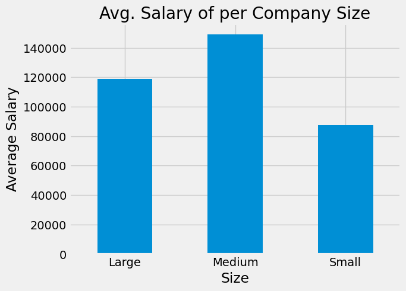

```python
avg_salary_compsize = companydf.groupby('Company Size')['Salary in USD'].mean()
avg_salary_compsize.plot(kind='bar')
plt.title('Avg. Salary of per Company Size')
plt.xlabel('Size')
plt.ylabel('Average Salary')
plt.xticks(rotation=0)
```

Bawed off of this graph, We can clearly see that medium size companies pay their employees the most followed by large then small. A reason for this can be that smaller companies don't have the money to pay their employees as much and larger companies may be trying to make a little extra coin and they have a lot of emplyees so they undermine a little bit. meanwhile companies that are in the middle have a good balance between income and employee count allowing them to provide their workers with sufficent pay.

# How has time effected avg. salaries?

```python
yearlydf=df.loc[:, ['Year', 'Salary in USD']]
yearlydf
```

|  | Year | Salary in USD |
| --- | --- | --- |
| 0 | 2024 | 138000 |
| 1 | 2024 | 86000 |
| 2 | 2024 | 179000 |
| 3 | 2024 | 112000 |
| 4 | 2024 | 92000 |
| ... | ... | ... |
| 5731 | 2020 | 412000 |
| 5732 | 2021 | 151000 |
| 5733 | 2020 | 105000 |
| 5734 | 2020 | 100000 |
| 5735 | 2021 | 94665 |

5736 rows × 2 columns

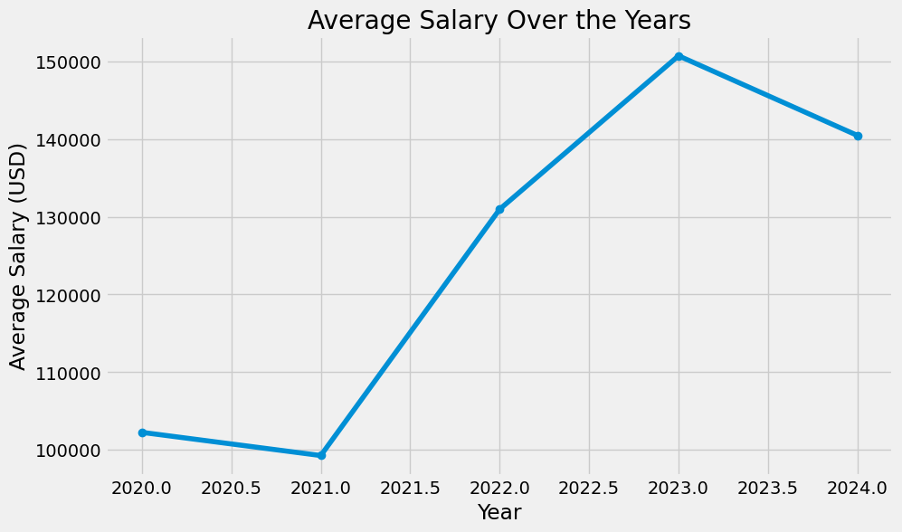

```python
average_salary = df.groupby('Year')['Salary in USD'].mean()
plt.figure(figsize=(10, 6))
plt.plot(average_salary.index, average_salary.values, marker='o', linestyle='-')
plt.title('Average Salary Over the Years')
plt.xlabel('Year')
plt.ylabel('Average Salary (USD)')
plt.grid(True)
plt.show()
```

With this graph we can see that from 2020 to 2021 there was a slight decine but after we had a sharp increase in the salaries and after a tiny drop. This is somehting that we will continue to see as time goes on because Data science is an evergrowing field and will always be improving and being built on. so for the forseeable future data science is seeming to be a very stable job.

# Takeaways

When examining our collected data and piecing together the bigger picture, several observations emerge. Let's start with experience level—it's common knowledge that as one gains more knowledge in their field, their pay increases accordingly. However, the amount of this pay increase is often not widely understood. through out analysis, we highlighted a significant finding: senior data scientists earn up to twice as much as entry-level counterparts. This insight is extremely helpful, providing clear information for entry-level job seekers about higher-paying roles and emphasizing the rewards of perseverance and dedication in career advancement. Additonally, it lets these seekers understand what they should be paid in years to come and allows them to have a sort of upperhand in job interviews by knowing what they are worth.

considering the Location of a company, understanding which countries offer the highest pay is particularly relevant in today's landscape, where remote work is increasingly sought after. This information serves as a valuable resource for individuals exploring remote work opportunities and seeking locations with favorable pay. Although this isn't something most people think about when applying for jobs it is still something to consider.

In summary, while the dataset offers straightforward insights and facilitates easy comparisons between variables, it's essential to keep an eye out for potential outliers and exercise caution in drawing conclusions. By leveraging the dataset's strengths and addressing its limitations, we can gain valuable insights to inform beginners need in order to break through in this field and get the pay that they deserve.